# 01-2. ITS2 preprocessing: Single- and paired-end comparison

QC20 / maxEE22 — Cutadapt and ITSxpress

2026-10-16

# 1 1. 분석 설계

## 1.1 입력과 비교 범위

- 입력은 `q20_ee22_both_full`의 Cutadapt single/paired 및 ITSxpress single/paired DADA2 feature table과 UNITE v10 99% taxonomy임.
- 네 pipeline 모두에서 공통인 동일 SampleID 83개를 사용함.
- 기존 `01_Preprocessing.Rmd`와 동일하게 taxonomy label을 정리한 뒤 `Kingdom == Fungi`와 zero-sum sample/taxon만 제거함.
- abundance threshold, singleton 제거, rarefaction 및 decontam은 적용하지 않음.
- Aitchison은 non-rarefied Species count에 pseudocount 0.5와 CLR을 적용함.
- 방법 비교는 동일 SampleID 내 paired 분석으로 수행함. PERMANOVA permutation은 SampleID 안에 제한하고, taxa/read/ASV 비교에는 paired Wilcoxon과 BH 보정을 적용함.

비교는 다음 네 쌍으로 제한함.

| Comparison | Method_1 | Method_2 |
| --- | --- | --- |
| Cutadapt: Single vs Paired | Cutadapt Single | Cutadapt Paired |
| ITSxpress: Single vs Paired | ITSxpress Single | ITSxpress Paired |
| Single-end: Cutadapt vs ITSxpress | Cutadapt Single | ITSxpress Single |
| Paired-end: Cutadapt vs ITSxpress | Cutadapt Paired | ITSxpress Paired |

`Cutadapt Single vs ITSxpress Paired`처럼 trimming 방식과 read 구조가 동시에 바뀌는 교차 조합은 분석하지 않음.

## 1.2 Sample 구성

| Sample_Type | Control_Type | Subject | PCR_Cycle_Group | N |
| --- | --- | --- | --- | --- |
| Control | Air swab | ASwab-C1 | PCR1_33__PCR2_8 | 1 |
| Control | Air swab | ASwab-C1 | PCR1_33__PCR2_10 | 1 |
| Control | Air swab | ASwab-C1 | PCR1_35__PCR2_8 | 1 |
| Control | Air swab | ASwab-C1 | PCR1_35__PCR2_10 | 1 |
| Control | Clean bench swab | CSwab-C1 | PCR1_33__PCR2_8 | 1 |
| Control | Clean bench swab | CSwab-C1 | PCR1_33__PCR2_10 | 1 |
| Control | Clean bench swab | CSwab-C1 | PCR1_35__PCR2_8 | 1 |
| Control | Clean bench swab | CSwab-C1 | PCR1_35__PCR2_10 | 1 |
| Control | Empty tube | ETube-C1 | PCR1_33__PCR2_8 | 1 |
| Control | Empty tube | ETube-C1 | PCR1_33__PCR2_10 | 1 |

[output cut: 10 more lines]

# 2 2. Phyloseq 생성 및 QC

## 2.1 전처리 전후 audit

| Method | Stage | Samples | Taxa | Total_Reads |
| --- | --- | --- | --- | --- |
| Cutadapt Single | Imported ASV table | 83 | 1860 | 1169781 |
| Cutadapt Single | Taxonomy cleaned | 83 | 1860 | 1169781 |
| Cutadapt Single | Kingdom == Fungi retained | 83 | 1860 | 1169781 |
| Cutadapt Single | Zero-sum samples/taxa removed | 83 | 1860 | 1169781 |
| Cutadapt Paired | Imported ASV table | 83 | 1301 | 954579 |
| Cutadapt Paired | Taxonomy cleaned | 83 | 1301 | 954579 |
| Cutadapt Paired | Kingdom == Fungi retained | 83 | 1301 | 954579 |
| Cutadapt Paired | Zero-sum samples/taxa removed | 83 | 1301 | 954579 |
| ITSxpress Single | Imported ASV table | 83 | 1202 | 960334 |
| ITSxpress Single | Taxonomy cleaned | 83 | 1202 | 960334 |

[output cut: 6 more lines]

네 pipeline 모두 83개 sample이 유지됨. 최종 fungal ASV는 Cutadapt Single 1860개, Cutadapt Paired 1301개, ITSxpress Single 1202개, ITSxpress Paired 1215개임.

| Method | ASV | Kingdom | Phylum | Class | Order | Family | Genus | Species |
| --- | --- | --- | --- | --- | --- | --- | --- | --- |
| Cutadapt Single | 1860 | 1 | 7 | 29 | 84 | 221 | 389 | 577 |
| Cutadapt Paired | 1301 | 1 | 7 | 27 | 73 | 181 | 299 | 431 |
| ITSxpress Single | 1202 | 1 | 6 | 30 | 87 | 223 | 397 | 611 |
| ITSxpress Paired | 1215 | 1 | 6 | 30 | 87 | 222 | 394 | 598 |

생성한 phyloseq object:

- Cutadapt Single RDS
- Cutadapt Paired RDS
- ITSxpress Single RDS
- ITSxpress Paired RDS

## 2.2 Read depth와 observed ASV

| Method | Sample_Type | N | Min | Q1 | Median | Q3 | Max |
| --- | --- | --- | --- | --- | --- | --- | --- |
| Cutadapt Single | Control | 12 | 567 | 1490.25 | 2138.5 | 3240.75 | 6982 |
| Cutadapt Single | True | 71 | 1332 | 9044 | 16145 | 21872.5 | 44979 |
| Cutadapt Paired | Control | 12 | 220 | 1095 | 1561 | 2619.75 | 6293 |
| Cutadapt Paired | True | 71 | 796 | 7140.5 | 13400 | 19144.5 | 41132 |
| ITSxpress Single | Control | 12 | 68 | 512.5 | 1438 | 2240.5 | 6272 |
| ITSxpress Single | True | 71 | 134 | 4567 | 8973 | 21824.5 | 45372 |
| ITSxpress Paired | Control | 12 | 42 | 491 | 1369.5 | 2139 | 5998 |
| ITSxpress Paired | True | 71 | 109 | 4312 | 7453 | 9610.5 | 16101 |

| Comparison | Metric | N_Pairs | Median_Method_1 | Median_Method_2 | Median_Ratio_Method_2_to_1 | P_value | P_adjust_BH |
| --- | --- | --- | --- | --- | --- | --- | --- |
| Cutadapt: Single vs Paired | Read_Depth | 83 | 14066 | 10834 | 0.8129855715871254 | 2.549524798426167e-15 | 8.177842782279082e-15 |
| Cutadapt: Single vs Paired | Observed_ASV | 83 | 60 | 43 | 0.676923076923077 | 5.416564934184587e-15 | 2.166625973673835e-14 |
| ITSxpress: Single vs Paired | Read_Depth | 83 | 7748 | 6692 | 0.908675799086758 | 4.088921391139541e-15 | 8.177842782279082e-15 |
| ITSxpress: Single vs Paired | Observed_ASV | 83 | 47 | 44 | 0.9343065693430657 | 4.784148825905508e-14 | 9.568297651811017e-14 |
| Single-end: Cutadapt vs ITSxpress | Read_Depth | 83 | 14066 | 7748 | 0.7559523809523809 | 4.987731051236242e-13 | 4.987731051236242e-13 |
| Single-end: Cutadapt vs ITSxpress | Observed_ASV | 83 | 60 | 47 | 0.8194444444444444 | 1.903143037139321e-13 | 2.537524049519094e-13 |
| Paired-end: Cutadapt vs ITSxpress | Read_Depth | 83 | 10834 | 6692 | 0.7315371991247265 | 3.981308803338158e-14 | 5.308411737784211e-14 |
| Paired-end: Cutadapt vs ITSxpress | Observed_ASV | 83 | 43 | 44 | 1.076923076923077 | 0.005550678122802304 | 0.005550678122802304 |

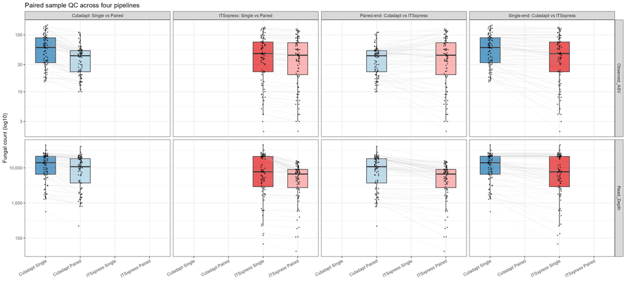

Observed ASV는 rarefaction 통과 여부나 filtering 기준이 아니라, 각 원본 fungal count table에서 sample별 non-zero ASV 수를 그대로 집계한 QC 지표임.

# 3 3. Aitchison beta diversity

## 3.1 네 pipeline 전체 개요

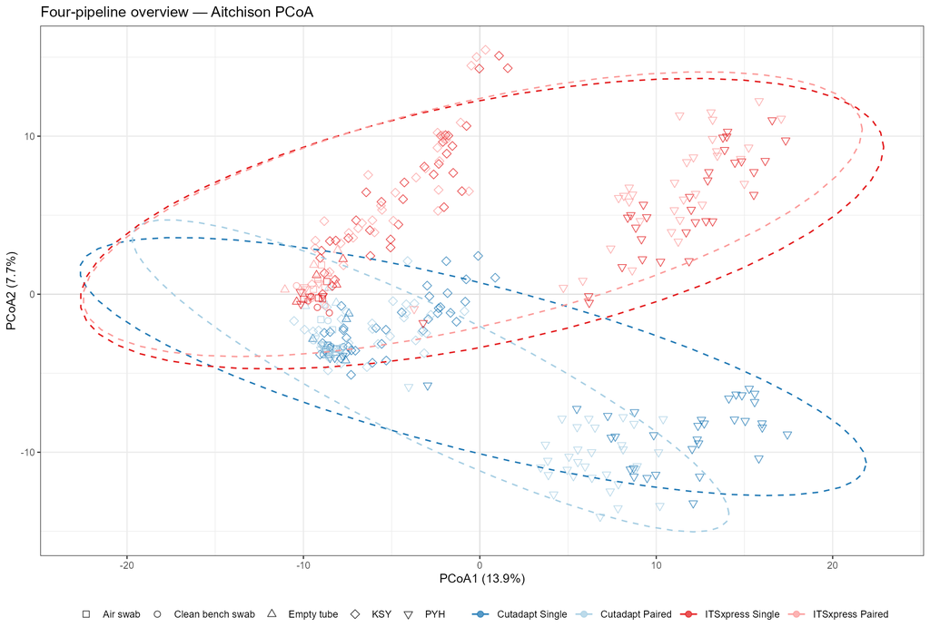

위 그림은 네 pipeline의 전체 배치를 보는 기술적 개요임. 직접적인 방법 효과 통계는 아래의 사전 지정된 네 paired comparison에서 판단함.

## 3.2 4분면 factorial contrast plane

일반 PCoA의 PC1/PC2를 임의로 Single–Paired 또는 ITSxpress–Cutadapt 축이라고 해석할 수는 없음. 따라서 아래 그림은 CLR Species 공간에서 두 방법 대비를 직접 정의한 supervised projection임.

- 가로축: 전체 sample에서 평균적인 `Paired → Single` 조성 변화 방향
- 세로축: read-mode 방향과 겹치는 성분을 제거한 `Cutadapt → ITSxpress` 조성 변화 방향
- 옅은 선: 동일 SampleID에서 read mode 또는 trimming 방법이 바뀔 때의 이동
- 큰 원과 label: 각 pipeline의 centroid
- 점 shape: control source 또는 Skin subject

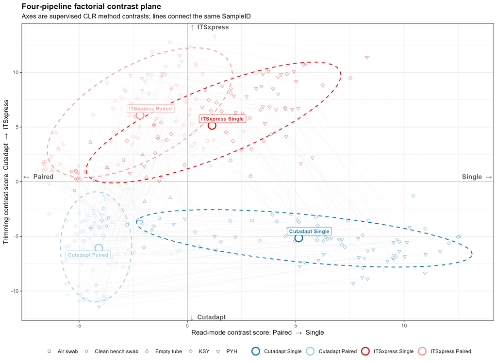

그림의 왼쪽은 Paired, 오른쪽은 Single, 위쪽은 ITSxpress, 아래쪽은 Cutadapt가 되도록 대비 방향을 고정함. 이는 데이터의 전체 변이를 최대화하는 비지도 PCoA가 아니라, 두 기술 요인의 변화를 읽기 위한 method-effect map임.

### 3.2.1 네 방법 동시 factorial PERMANOVA

| Term | Df | SumOfSqs | R2 | F | P_value | P_adjust_BH |
| --- | --- | --- | --- | --- | --- | --- |
| Trimming | 1 | 10536.17626478961 | 0.05787324481698911 | 20.85166313097193 | 0.001 | 0.001 |
| Read_Mode | 1 | 3268.658474880101 | 0.01795412940955006 | 6.468852047983212 | 0.001 | 0.001 |
| Trimming:Read_Mode | 1 | 2515.50852118695 | 0.01381721763448323 | 4.978327523066268 | 0.001 | 0.001 |

| Test | F_value | P_value |
| --- | --- | --- |
| Four-pipeline betadisper | 3.579139009016778 | 0.02 |

- Trimming 주효과는 R² 0.058, read mode 주효과는 R² 0.018임.
- `Trimming × Read_Mode` 상호작용도 R² 0.014로 확인됨. 즉 ITSxpress–Cutadapt 차이의 크기 또는 방향이 Single과 Paired에서 완전히 동일하지 않음.
- 네 pipeline 전체 betadisper p-value는 0.02이므로, 동시 PERMANOVA의 일부는 group dispersion 차이를 포함할 수 있음. 따라서 effect size와 4분면 이동 패턴을 함께 해석함.

## 3.3 ASV 단위 2×2 차등풍부도 4분면

위 3.2 그림의 점은 sample profile이므로 ASV 차등풍부도 그림이 아님. 아래 그림은 요청한 대로 **각 점이 하나의 ASV 비교 단위**임.

네 pipeline은 동일 생물학적 서열도 서로 다른 길이와 FeatureID를 만들기 때문에 raw ASV ID를 직접 합치지 않음. 비교 전에 exact identity 또는 100 bp 이상 exact containment로 동일 sequence family를 정의함. 이 매핑은 ASV overlap을 결과로 해석하기 위한 것이 아니라, 네 pipeline에서 동일한 차등풍부도 단위를 확보하기 위한 전처리임.

| Metric | N |
| --- | --- |
| Raw ASVs across four pipelines | 5578 |
| Exact-containment edges | 4257 |
| ASV sequence families | 2136 |
| Families represented in &gt;=2 pipelines | 1379 |
| Single-pipeline families | 757 |
| Ambiguous families | 195 |

- 가로축: 동일 SampleID에서 계산한 평균 CLR `Paired → Single` 효과
- 세로축: 동일 SampleID에서 계산한 평균 CLR `Cutadapt → ITSxpress` 효과
- 각 ASV family마다 83개의 paired contrast를 0과 비교하는 Wilcoxon signed-rank test를 수행함.
- read mode, trimming 및 interaction을 각각 검정하고 각 contrast에서 전체 2136개 ASV family에 BH 보정함.
- abundance/prevalence filtering은 적용하지 않았으며 pseudocount는 기존 Aitchison 분석과 동일한 0.5임.

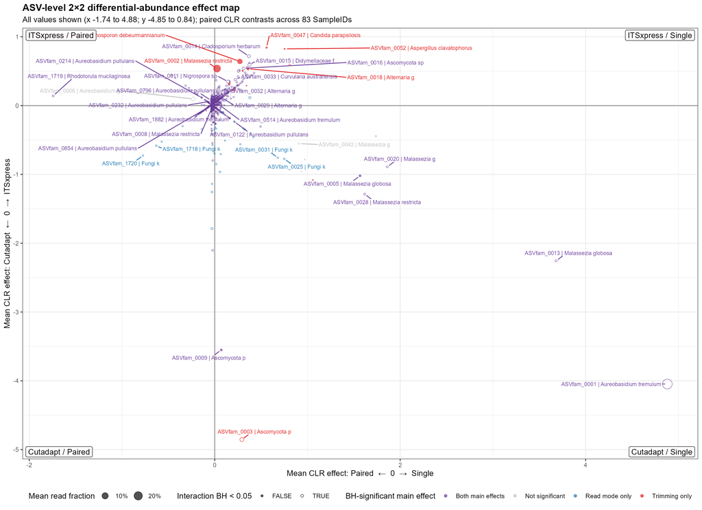

점의 색은 BH 보정 후 유의한 main effect 유형이며, 빈 원은 trimming × read-mode interaction도 BH < 0.05인 ASV family임. 점 크기는 네 pipeline에서의 평균 fungal read fraction임.

그림은 극단값을 제거하거나 축을 자르지 않은 **전체 범위**임. 아래 표의 1%와 99% 분위수도 함께 제시하여, 소수의 매우 큰 효과가 중앙 점군을 압축하는 정도를 확인함.

| Contrast | Minimum | P01 | Median | P99 | Maximum |
| --- | --- | --- | --- | --- | --- |
| Interaction | -4.746564491821514 | -0.7530571424704798 | 0.02119621197387593 | 0.2863753945554334 | 8.406840423308111 |
| Read mode | -1.741915402879032 | -0.1457494841309167 | -0.01857361457492583 | 0.380841991110022 | 4.880549978429434 |
| Trimming | -4.853588291028429 | -0.718632012438293 | 0.01158894772516971 | 0.4021674430169674 | 0.843173104942371 |

대표 taxonomy는 이제 family 내 read 수만으로 정하지 않고, 먼저 가장 세부적으로 분류된 이름을 선택한 뒤 동일 분류 수준에서 read 수가 큰 ASV를 선택함. 따라서 ITSxpress의 `Fungi_k` 서열과 동일 family로 연결된 Cutadapt의 species-level call이 가려지지 않음. 특히 `ASVfam_0001`에는 Cutadapt Paired의 주요 `Aureobasidium tremulum` ASV가 포함되며, 이 family가 read-mode 최대 효과 부근에 위치함.

| ASV_Family | Representative_Taxon | Methods_in_Family | Ambiguous_Family | Mean_Read_Mode_Effect | Mean_Trimming_Effect | Mean_Interaction | Q_Read_Mode | Q_Trimming | Q_Interaction | Mean_Read_Fraction | Raw_Total_Reads |
| --- | --- | --- | --- | --- | --- | --- | --- | --- | --- | --- | --- |
| ASVfam_0001 | Aureobasidium tremulum | 3 | True | 4.880549978429434 | -4.046476941027061 | 8.406840423308111 | 1.005278476667904e-14 | 1.530739358764678e-10 | 2.465349124643296e-14 | 0.2919426750929673 | 1191710 |
| ASVfam_0006 | Aureobasidium g | 4 | True | -0.2317177872234075 | 0.09614780620547121 | -0.3923465651079961 | 0.6586261344120946 | 0.6539029530397374 | 2.901075222954823e-06 | 0.02821837584739763 | 97530 |
| ASVfam_0122 | Aureobasidium pullulans | 3 | False | 0.2094257465443985 | -0.2309701373084048 | 0.5320304466713546 | 1.131024898695604e-08 | 0.003952268024073322 | 7.824403691721685e-15 | 0.0003642127507154977 | 1485 |
| ASVfam_0214 | Aureobasidium pullulans | 4 | False | -0.1380740990143784 | 0.112955490507419 | -0.1617269290803375 | 4.384675818160907e-12 | 0.0005321466066991145 | 3.350172990746566e-11 | 0.0002871028791515626 | 894 |
| ASVfam_0232 | Aureobasidium pullulans | 4 | False | -0.0303917444549669 | 0.06545252929160854 | 0.04986616482232662 | 4.480072877079199e-13 | 0.0004996464008005958 | 2.138142356627096e-13 | 0.0002057633556917003 | 690 |
| ASVfam_0796 | Aureobasidium pullulans | 4 | False | -0.0380852269442249 | 0.0732148159171538 | 0.04148739724752789 | 8.549112981849753e-15 | 0.0004996464008005958 | 9.235768647319413e-13 | 4.496505344852313e-05 | 139 |
| ASVfam_0514 | Aureobasidium tremulum | 2 | False | 0.04772472459895996 | 0.01251972594278418 | 0.05004052378885421 | 6.376333350620758e-14 | 0.0004996464008005958 | 7.824403691721685e-15 | 2.884657997446295e-05 | 119 |
| ASVfam_0854 | Aureobasidium pullulans | 4 | False | -0.03111478127262135 | 0.006096393295680761 | 0.05495206558298971 | 6.376333350620758e-14 | 0.0005551532724125419 | 7.824403691721685e-15 | 2.27275348732877e-05 | 79 |
| ASVfam_1882 | Aureobasidium tremulum | 1 | False | -0.05777719674479749 | -0.01020671685177562 | 0.09375486032361635 | 8.549112981849753e-15 | 0.001022372633436903 | 7.824403691721685e-15 | 2.169770109877354e-06 | 6 |

| Main_Effect_Significance | Interaction_Significant | N_ASV_Families |
| --- | --- | --- |
| Both main effects | False | 2 |
| Both main effects | True | 2079 |
| Not significant | False | 6 |
| Not significant | True | 3 |
| Read mode only | False | 1 |
| Read mode only | True | 33 |
| Trimming only | False | 10 |
| Trimming only | True | 2 |

| ASV_Family | Representative_Taxon | Methods_in_Family | Ambiguous_Family | Mean_Read_Mode_Effect | Q_Read_Mode | Mean_Trimming_Effect | Q_Trimming | Mean_Interaction | Q_Interaction | Mean_Read_Fraction |
| --- | --- | --- | --- | --- | --- | --- | --- | --- | --- | --- |
| ASVfam_0001 | Aureobasidium tremulum | 3 | True | 4.880549978429434 | 1.005278476667904e-14 | -4.046476941027061 | 1.530739358764678e-10 | 8.406840423308111 | 2.465349124643296e-14 | 0.2919426750929673 |
| ASVfam_0002 | Malassezia restricta | 4 | True | 0.02494206307799385 | 0.0682783527453993 | 0.5379308973839111 | 0.01551943219092766 | 0.01601866565370519 | 0.1607227179226285 | 0.158555156171424 |
| ASVfam_0004 | Cutaneotrichosporon debeurmannianum | 4 | True | 0.271586157056709 | 0.3765207099694199 | 0.641939283346885 | 5.355446669110066e-10 | -0.3584723434817558 | 0.05555294660195226 | 0.06714691345959617 |
| ASVfam_0003 | Ascomycota p | 2 | True | 0.2926007765953619 | 0.5272464528245258 | -4.853588291028429 | 5.355446669110066e-10 | -0.6070010863567026 | 0.005186937022471062 | 0.03150349240569474 |
| ASVfam_0007 | Rhodotorula mucilaginosa | 4 | False | 0.1517296799415909 | 0.4903115286826755 | 0.1493891655854163 | 0.07678631645922938 | -0.06690741418482224 | 9.030237430953147e-05 | 0.02960074602045227 |
| ASVfam_0008 | Malassezia restricta | 4 | True | -0.01555564941602469 | 1.006513955326144e-06 | 0.01444919170211939 | 0.0001806049108320087 | 0.02581891372889455 | 4.397836265923071e-10 | 0.02399125696777223 |
| ASVfam_0006 | Aureobasidium g | 4 | True | -0.2317177872234075 | 0.6586261344120946 | 0.09614780620547121 | 0.6539029530397374 | -0.3923465651079961 | 2.901075222954823e-06 | 0.02821837584739763 |
| ASVfam_0015 | Didymellaceae f | 4 | True | 0.3749099396349931 | 0.000773205032476125 | 0.5940471636555856 | 4.491077177249735e-05 | -0.7677442552180453 | 0.0007724703958656964 | 0.01603050170813474 |
| ASVfam_0011 | Nigrospora sp | 4 | False | 0.1455826884274409 | 6.359349702161125e-06 | 0.3474755112795063 | 6.533622433326565e-12 | -0.1611473601918769 | 9.549931643321305e-05 | 0.01703770970455016 |
| ASVfam_0005 | Malassezia globosa | 4 | True | 1.566879029242891 | 0.03416255696227177 | -1.019933828198878 | 0.0003902797168907571 | -2.161202616113184 | 0.06883965866678317 | 0.008050785412552962 |

[output cut: 20 more lines]

2115개 family에서 read-mode 효과, 2093개에서 trimming 효과, 2117개에서 interaction이 확인됨. 이렇게 광범위한 유의성은 생물학적 ASV 변화가 아니라 **동일 library를 서로 다른 trimming/read 구조로 처리하면서 ASV boundary와 count allocation이 체계적으로 바뀐 기술적 differential abundance**를 의미함.

특히 single-pipeline family가 757개이고, 한 pipeline 내 여러 ASV가 동일 family로 연결된 ambiguous family가 195개이므로, 개별 ASV family의 taxonomic 의미보다 effect direction과 abundance가 큰 family를 우선 해석해야 함.

## 3.4 Paired method effect

| Comparison | Method_1 | Method_2 | N_Pairs | PERMANOVA_R2 | PERMANOVA_P | Betadisper_P | Procrustes_r | PROTEST_P | PERMANOVA_P_BH | Betadisper_P_BH |
| --- | --- | --- | --- | --- | --- | --- | --- | --- | --- | --- |
| Cutadapt: Single vs Paired | Cutadapt Single | Cutadapt Paired | 83 | 0.05346912964616343 | 0.001 | 0.006 | 0.9759719230073464 | 0.001 | 0.001 | 0.024 |
| ITSxpress: Single vs Paired | ITSxpress Single | ITSxpress Paired | 83 | 0.01526592363894063 | 0.001 | 0.779 | 0.9956750802490125 | 0.001 | 0.001 | 0.873 |
| Single-end: Cutadapt vs ITSxpress | Cutadapt Single | ITSxpress Single | 83 | 0.06207102798809141 | 0.001 | 0.873 | 0.9865411116029164 | 0.001 | 0.001 | 0.873 |
| Paired-end: Cutadapt vs ITSxpress | Cutadapt Paired | ITSxpress Paired | 83 | 0.08548757903213391 | 0.001 | 0.016 | 0.9555645028328771 | 0.001 | 0.001 | 0.032 |

- PERMANOVA는 paired method-location 차이를 평가함.
- `betadisper`가 유의한 비교는 centroid 이동뿐 아니라 dispersion 차이도 포함할 수 있으므로 순수한 위치 효과로 단정하지 않음.
- Procrustes correlation은 두 pipeline에서 sample 간 배치 구조가 얼마나 보존되는지를 평가함.

### 3.4.1 Cutadapt: Single vs Paired

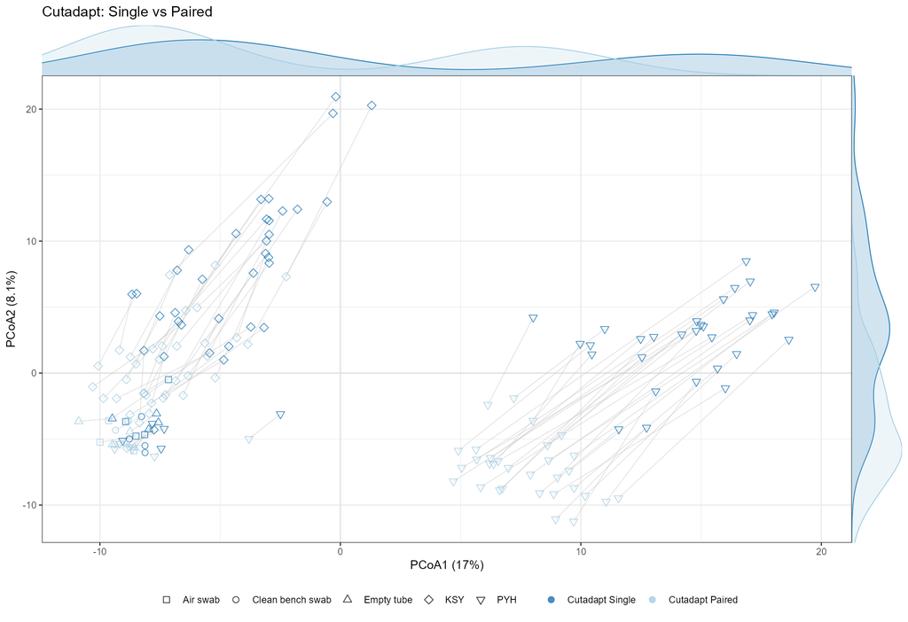

### 3.4.2 ITSxpress: Single vs Paired

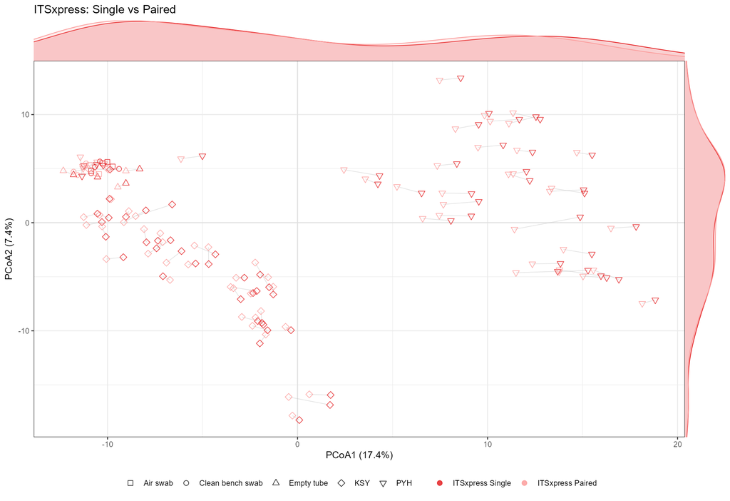

### 3.4.3 Single-end: Cutadapt vs ITSxpress

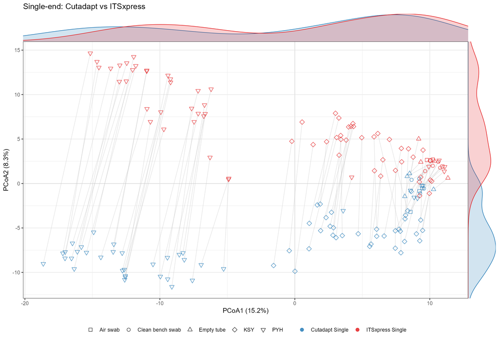

### 3.4.4 Paired-end: Cutadapt vs ITSxpress

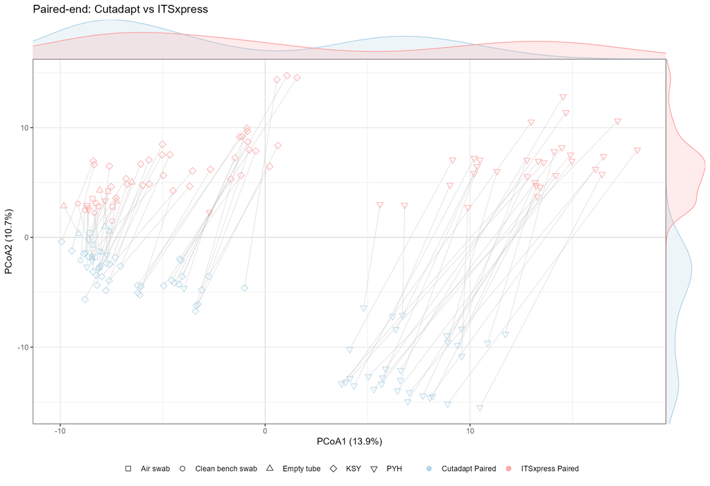

# 4 4. Species-level taxa 비교

## 4.1 Species overlap

| Comparison | Method_1 | Method_2 | Detected_Method_1 | Detected_Method_2 | Shared | Method_1_only | Method_2_only |
| --- | --- | --- | --- | --- | --- | --- | --- |
| Cutadapt: Single vs Paired | Cutadapt Single | Cutadapt Paired | 577 | 431 | 350 | 227 | 81 |
| ITSxpress: Single vs Paired | ITSxpress Single | ITSxpress Paired | 611 | 598 | 569 | 42 | 29 |
| Single-end: Cutadapt vs ITSxpress | Cutadapt Single | ITSxpress Single | 577 | 611 | 491 | 86 | 120 |
| Paired-end: Cutadapt vs ITSxpress | Cutadapt Paired | ITSxpress Paired | 431 | 598 | 343 | 88 | 255 |

## 4.2 Paired abundance difference

각 점은 sample이나 ASV가 아니라 동일 Species fallback label로 합산한 뒤 83개 sample에서 평균한 taxon임. 각 비교의 상위 14 taxa만 이름을 표시함.

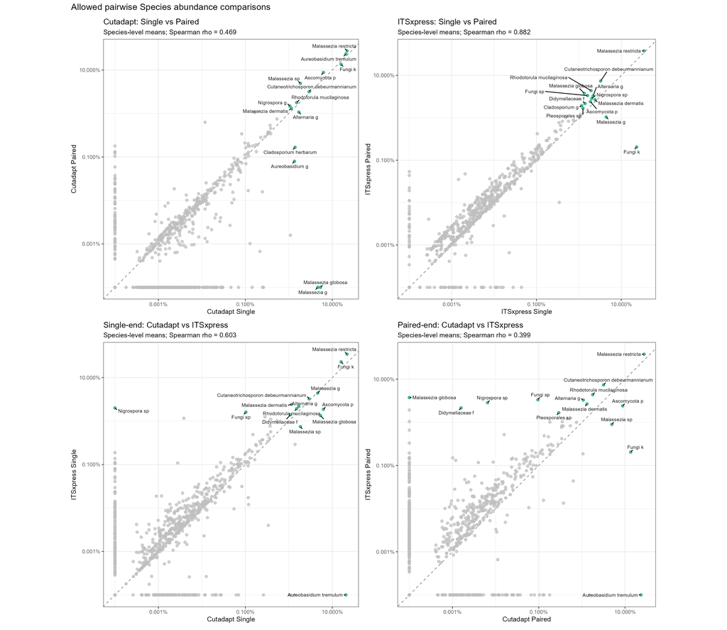

| Species | Comparison | Method_1 | Method_2 | N_Pairs | Mean_Method_1 | Mean_Method_2 | Mean_Difference_2_minus_1 | P_value | P_adjust_BH |
| --- | --- | --- | --- | --- | --- | --- | --- | --- | --- |
| Malassezia restricta | Cutadapt: Single vs Paired | Cutadapt Single | Cutadapt Paired | 83 | 0.2190160573572291 | 0.2761919569292295 | 0.05717589957200041 | 2.387180885093001e-14 | 3.342053239130202e-13 |
| Cladosporium herbarum | Cutadapt: Single vs Paired | Cutadapt Single | Cutadapt Paired | 83 | 0.01391491269651221 | 0.001672476208009388 | -0.01224243648850282 | 1.758050825821494e-12 | 8.204237187166973e-12 |
| Malassezia globosa | Cutadapt: Single vs Paired | Cutadapt Single | Cutadapt Paired | 83 | 0.0535186481713268 | 0 | -0.0535186481713268 | 1.679106030999023e-12 | 8.204237187166973e-12 |
| Malassezia g | Cutadapt: Single vs Paired | Cutadapt Single | Cutadapt Paired | 83 | 0.04618039268870366 | 0 | -0.04618039268870366 | 2.452427773137773e-11 | 8.583497205982207e-11 |
| Aureobasidium tremulum | Cutadapt: Single vs Paired | Cutadapt Single | Cutadapt Paired | 83 | 0.2053446463677161 | 0.2335763184443253 | 0.02823167207660918 | 1.573252077988143e-09 | 4.405105818366799e-09 |
| Malassezia dermatis | Cutadapt: Single vs Paired | Cutadapt Single | Cutadapt Paired | 83 | 0.01150656486736762 | 0.01311741818910338 | 0.001610853321735758 | 2.694407352402341e-07 | 6.286950488938795e-07 |
| Aureobasidium g | Cutadapt: Single vs Paired | Cutadapt Single | Cutadapt Paired | 83 | 0.01348017056670084 | 0.0007945138461303514 | -0.01268565672057048 | 2.012528480926365e-06 | 4.025056961852731e-06 |
| Rhodotorula mucilaginosa | Cutadapt: Single vs Paired | Cutadapt Single | Cutadapt Paired | 83 | 0.01516410670616034 | 0.01782018518648257 | 0.00265607848032223 | 3.013011565991952e-06 | 5.272770240485915e-06 |
| Alternaria g | Cutadapt: Single vs Paired | Cutadapt Single | Cutadapt Paired | 83 | 0.01699687558519628 | 0.010774907509829 | -0.006221968075367282 | 0.0002633252680733851 | 0.0004096170836697102 |
| Cutaneotrichosporon debeurmannianum | Cutadapt: Single vs Paired | Cutadapt Single | Cutadapt Paired | 83 | 0.02930488108964262 | 0.03171382379055958 | 0.002408942700916965 | 0.0003605430583676344 | 0.0005047602817146881 |

[output cut: 46 more lines]

이 표의 BH 보정은 각 comparison에서 선정된 상위 14 Species 안에서 수행함. 따라서 논문용 전체 differential-abundance 검정이 아니라 preprocessing 방법에 따른 주요 조성 변화의 기술적 비교임.

# 5 5. Sample별 Species composition

- 각 막대는 개별 SampleID임.
- 네 그림에 동일한 top Species 목록과 `RColorBrewer` Paired/Dark2 기반 색을 사용함.
- facet은 Subject/control source와 PCR cycle 조합이며 `nrow = 1`로 가로 배치함.
- HTML에는 축소 preview를 표시하고 원본은 42-inch wide PNG로 별도 저장함.

## 5.1 Cutadapt Single

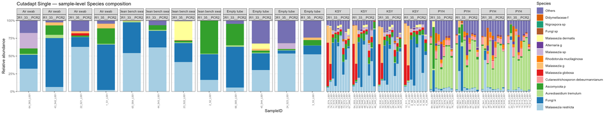

고해상도 PNG 열기

## 5.2 Cutadapt Paired

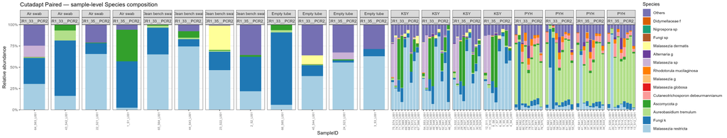

고해상도 PNG 열기

## 5.3 ITSxpress Single

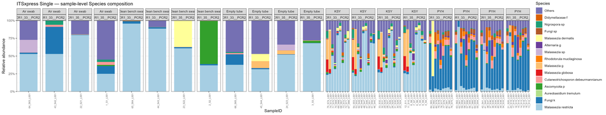

고해상도 PNG 열기

## 5.4 ITSxpress Paired

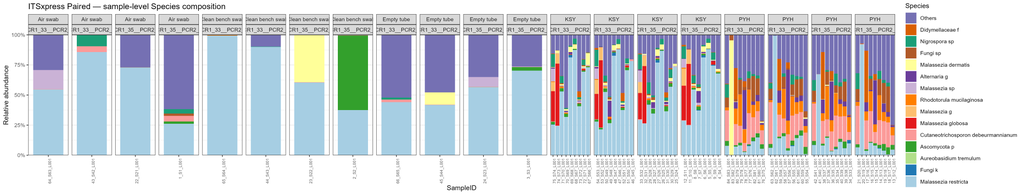

고해상도 PNG 열기

# 6 6. ASV sequence length와 frequency

| Method | ASVs | Median_Length | Q1_Length | Q3_Length | Min_Length | Max_Length | Total_Reads |
| --- | --- | --- | --- | --- | --- | --- | --- |
| Cutadapt Paired | 1301 | 335 | 284 | 355 | 33 | 516 | 954579 |
| Cutadapt Single | 1860 | 281 | 278 | 281 | 26 | 282 | 1169781 |
| ITSxpress Paired | 1215 | 191 | 160.5 | 208 | 56 | 369 | 536398 |
| ITSxpress Single | 1202 | 172 | 159 | 173 | 30 | 176 | 960334 |

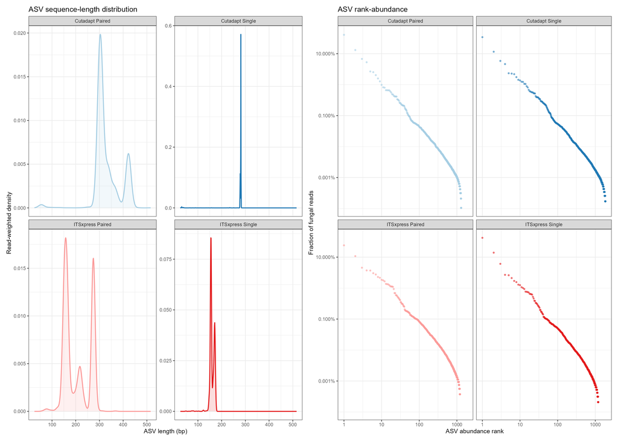

- Single-end ASV의 최대 길이는 Cutadapt 282 bp, ITSxpress 176 bp로 read truncation의 직접적인 영향을 받음.
- 따라서 Single vs Paired에서 ASV identity가 달라지는 것은 예상되는 결과이며, ASV ID 자체를 직접 일치시키기보다 Species-level composition과 동일 sample의 ordination 구조를 주 비교 대상으로 삼음.
- length density는 ASV 개수뿐 아니라 각 ASV의 fungal read 수로 가중함.

# 7 7. 종합 요약

- **Cutadapt: Single vs Paired**: paired Aitchison PERMANOVA R² = 0.053, BH p = 0.001; betadisper BH p = 0.024; Procrustes r = 0.976.
- **ITSxpress: Single vs Paired**: paired Aitchison PERMANOVA R² = 0.015, BH p = 0.001; betadisper BH p = 0.873; Procrustes r = 0.996.
- **Single-end: Cutadapt vs ITSxpress**: paired Aitchison PERMANOVA R² = 0.062, BH p = 0.001; betadisper BH p = 0.873; Procrustes r = 0.987.
- **Paired-end: Cutadapt vs ITSxpress**: paired Aitchison PERMANOVA R² = 0.085, BH p = 0.001; betadisper BH p = 0.032; Procrustes r = 0.956.
- 모든 비교에서 동일한 83개 sample과 동일한 fungal/zero-sum 처리 규칙을 사용함.
- Cutadapt Single은 네 pipeline 중 fungal read와 ASV가 가장 많았지만, 이 차이는 곧바로 생물학적 다양성 증가를 뜻하지 않으며 single-end read structure와 denoising 결과 차이를 포함함.
- `betadisper`가 유의한 비교에서는 PERMANOVA 차이의 일부가 dispersion 변화에서 유래할 수 있음.
- 본 보고서는 preprocessing 방법 선택의 기술적 비교이며, alpha/beta biological inference와 decontam 분석은 선택된 phyloseq object를 이용해 다음 Basic analysis에서 수행해야 함.

# 8 8. 재현 파일

- 전체 분석 R script
- 전체 중간 object RDS
- Beta statistics CSV
- Factorial PERMANOVA CSV
- 4분면 centroid CSV
- ASV family mapping audit CSV
- ASV family membership CSV
- ASV 2×2 differential-abundance 전체 결과 CSV
- Species paired tests CSV
- ASV sequence summary CSV

## 8.1 한계

- rarefaction은 적용하지 않았으며 이 보고서의 Aitchison 분석에는 필요하지 않음.
- Bray–Curtis/Jaccard, alpha diversity 및 decontam 결과는 본 preprocessing 보고서에서 filtering 기준을 임의로 정하지 않기 위해 수행하지 않음.
- single-end와 paired-end는 관찰 가능한 서열 길이가 다르므로 ASV 수와 taxonomy resolution 차이를 sequencing depth 차이 하나로만 설명할 수 없음.
- taxa 검정은 compositional dependency와 반복 PCR 구조를 완전히 모형화한 differential-abundance 분석이 아니라 paired descriptive screen임.